# NIL Genotype Plotting and Genotype Correlation Analysis of Inv4m Introgression

Fausto Rodriguez Zapata

2026-05-07

# Overview

**Purpose**: Plot genotype per NIL. Characterize linkage disequilibrium between the Inv4m chromosomal inversion and genome-wide markers in maize near-isogenic lines.

**Expected outcome**: Identify the physical extent of linkage with Inv4m, detect recombination breakpoints, and characterize flanking introgression segments.

# Load Libraries

```r
library(vcfR)
library(dplyr)
library(ggplot2)
library(ggtext)
library(rtracklayer)
library(GenomicRanges)
library(cowplot)
```

# Define Genomic Regions

**Purpose**: Establish coordinates for Inv4m inversion and shared introgression.

**Approach**: Extract gene boundaries from B73 v5.0 annotation to define inversion breakpoints identified in MCScan analysis.

```r
# Load B73 annotation
myGFF <- file.path(paths$data, "Zea_mays.Zm-B73-REFERENCE-NAM-5.0.59.chr.gff3")
B73 <- rtracklayer::import(myGFF) %>%
  subset(type == "gene" & seqnames %in% 1:10)

genes <- as.data.frame(B73)
genes$ID <- gsub("gene:", "", genes$ID)

# Inv4m boundaries (from MCScan)
inv4m_start <- genes[genes$ID == "Zm00001eb190470", "start"]
inv4m_end <- genes[genes$ID == "Zm00001eb194800", "end"]

# Shared introgression boundaries (empirical)
introgression_start <- 157012149
introgression_end <- 195900523

# Create GRanges objects
inv4m <- GRanges(
  seqnames = "4",
  ranges = IRanges(start = inv4m_start, end = inv4m_end),
  strand = "+"
)

shared_introgression <- GRanges(
  seqnames = "4",
  ranges = IRanges(start = introgression_start, end = introgression_end),
  strand = "+"
)

# Region sizes
inv4m_size <- round((inv4m_end - inv4m_start) / 1e6, 1)
introgression_size <- round((introgression_end - introgression_start) / 1e6, 1)

# Count genes in regions
olap_inv4m <- findOverlaps(inv4m, B73, ignore.strand = TRUE)
inv4m_gene_ids <- genes$ID[subjectHits(olap_inv4m)]

olap_introgression <- findOverlaps(shared_introgression, B73, ignore.strand = TRUE)
shared_introgression_gene_ids <- genes$ID[subjectHits(olap_introgression)]

flanking_introgression_gene_ids <- shared_introgression_gene_ids[
  !(shared_introgression_gene_ids %in% inv4m_gene_ids)
]

cat("Inv4m inversion:", inv4m_size, "Mb |", length(inv4m_gene_ids), "genes\n")
```

```
## Inv4m inversion: 15.2 Mb | 434 genes
```

```r
cat("Shared introgression:", introgression_size, "Mb |",
    length(shared_introgression_gene_ids), "genes\n")
```

```
## Shared introgression: 38.9 Mb | 1101 genes
```

```r
cat("Flanking regions:",
    round(introgression_size - inv4m_size, 1), "Mb |",
    length(flanking_introgression_gene_ids), "genes\n")
```

```
## Flanking regions: 23.7 Mb | 667 genes
```

# Import and Process VCF

**Purpose**: Load genotype data and convert to numeric matrix.

**Approach**: Read VCF, extract GT field, recode genotypes as 0/1/2 for B73/Het/Mi21.

```r
# Read VCF
vcf <- read.vcfR(file.path(paths$data, "inv4m_PSU_imputed.vcf"))
```

[output not shown]

```r
gt <- extract.gt(vcf, element = "GT")

# Recode genotypes
gt[gt == "0/0"] <- 0
gt[gt == "0/1" | gt == "1/0"] <- 1
gt[gt == "1/1"] <- 2

# Convert to numeric matrix
ngt <- matrix(as.integer(gt), ncol = ncol(gt))
colnames(ngt) <- colnames(gt)
rownames(ngt) <- rownames(gt)

# Sample ordering (CTRL then INV4 carriers, alphabetically within group)
sample_order <- c(
  sort(c("3095", "3113", "4113", "3083", "4107", "4122")),
  sort(c("3092", "3080", "3059", "3131", "4125", "4080", "4131"))
)

ngt <- ngt[, sample_order] %>% t()

# Genotype distribution (by site)
total_sites <- ncol(ngt) * nrow(ngt)
geno_freq <- table(ngt) / total_sites
cat("Genotype frequencies (by site):\n")
```

```
## Genotype frequencies (by site):
```

```r
cat("  B73/B73 (0):", round(geno_freq["0"], 3), "\n")
```

```
##   B73/B73 (0): 0.636
```

```r
cat("  B73/Mi21 (1):", round(geno_freq["1"], 3), "\n")
```

```
##   B73/Mi21 (1): 0.09
```

```r
cat("  Mi21/Mi21 (2):", round(geno_freq["2"], 3), "\n")
```

```
##   Mi21/Mi21 (2): 0.273
```

```r
cat("  Missing:", round(sum(is.na(ngt)) / total_sites, 4), "\n")
```

```
##   Missing: 0.0016
```

```r
cat("Dimensions:", nrow(ngt), "samples ×", ncol(ngt), "markers\n")
```

```
## Dimensions: 13 samples × 19861 markers
```

# Genotype Run Analysis

**Purpose**: Quantify introgression content across samples.

**Approach**: Calculate run-length encoding of genotypes, sum by allelic state.

```r
get_genotype_runs <- function(x, sample_order) {
  result <- data.frame()
  chr_levels <- paste0("S", 1:10)

  for (ind_idx in sample_order) {
    result_ind <- data.frame()

    for (chr_idx in 1:10) {
      chr_prefix <- paste0("S", chr_idx, "_")
      chr_name <- paste0("S", chr_idx)
      chr <- x[grepl(chr_prefix, rownames(x), perl = TRUE), ]
      runs <- rle(chr[, ind_idx])

      chr_long <- data.frame(
        ind = ind_idx,
        chr = chr_name,
        pos = as.integer(gsub(chr_prefix, "", names(runs$values))),
        gt = runs$values
      ) %>%
        group_by(ind, chr) %>%
        mutate(
          lag = lag(pos, default = 0),
          span = (pos - lag) / 1e6,
          chr = factor(chr, levels = chr_levels),
          ind = factor(ind, levels = sample_order),
          missing = is.na(gt),
          missing_length = missing * span,
          B73 = as.numeric(gt == 0),
          B73_length = B73 * span,
          Het = as.numeric(gt == 1),
          Het_length = Het * span,
          Mi21 = as.numeric(gt == 2),
          Mi21_length = Mi21 * span
        )

      result_ind <- rbind(result_ind, chr_long)
    }

    result <- rbind(result, result_ind)
  }
  result
}

# Calculate runs
m <- t(ngt)
gt_runs <- get_genotype_runs(m, sample_order)

# Add grouping
gt_runs$group <- case_when(
  gt_runs$ind %in% c("3092", "3080", "3059", "3131", "4125", "4080", "4131") ~
    "Inv4m",
  .default = "CTRL"
)

# Genome size
chr_length <- gt_runs %>%
  group_by(chr) %>%
  summarise(chr_length = max(pos) / 1e6)
genome_size <- sum(chr_length$chr_length)

# Summarize by genotype
by_length <- gt_runs %>%
  inner_join(chr_length, by = "chr") %>%
  ungroup() %>%
  group_by(ind) %>%
  summarise(
    B73 = sum(B73_length, na.rm = TRUE),
    Het = sum(Het_length, na.rm = TRUE),
    Mi21 = sum(Mi21_length, na.rm = TRUE),
    missing = sum(missing_length, na.rm = TRUE),
    group = group[1]
  ) %>%
  mutate(group = factor(group, levels = c("CTRL", "Inv4m"))) %>%
  tidyr::pivot_longer(
    cols = c("B73", "Het", "Mi21", "missing"),
    names_to = "Genotype",
    values_to = "length"
  ) %>%
  mutate(pct = 100 * length / genome_size)

cat("Genome size:", round(genome_size, 1), "Mb\n")
```

```
## Genome size: 2128.1 Mb
```

```r
cat("\nGenotype run length summary (Mb):\n")
```

```
##
## Genotype run length summary (Mb):
```

```r
by_length %>%
  group_by(Genotype) %>%
  summarise(
    mean_Mb = round(mean(length), 1),
    mean_pct = round(mean(pct), 2)
  ) %>%
  print()
```

```
## # A tibble: 4 × 3
##   Genotype mean_Mb mean_pct
##   <chr>      <dbl>    <dbl>
## 1 B73       1821.     85.6
## 2 Het        183.      8.61
## 3 Mi21       117.      5.5
## 4 missing      7.3     0.34
```

```r
cat("\nBy introgression group:\n")
```

```
##
## By introgression group:
```

```r
by_length %>%
  group_by(group, Genotype) %>%
  summarise(
    mean_Mb = round(mean(length), 1),
    mean_pct = round(mean(pct), 2),
    .groups = "drop"
  ) %>%
  print()
```

```
## # A tibble: 8 × 4
##   group Genotype mean_Mb mean_pct
##   <fct> <chr>      <dbl>    <dbl>
## 1 CTRL  B73       1849.     86.9
## 2 CTRL  Het        170       7.99
## 3 CTRL  Mi21       102       4.79
## 4 CTRL  missing      6.8     0.32
## 5 Inv4m B73       1796.     84.4
## 6 Inv4m Het        195.      9.15
## 7 Inv4m Mi21       130.      6.1
## 8 Inv4m missing      7.8     0.37
```

# Genotype Visualization

**Purpose**: Create chromosome-wide haplotype plots.

**Approach**: Plot genotype runs as colored bars across chromosomes.

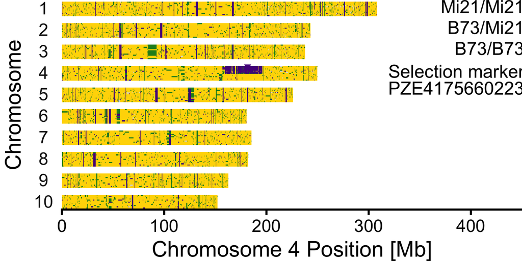

```r
# Genotype color palette (3 colors at values 0, 1, 2)
gt_colors <- c("gold", "forestgreen", "purple4")
gt_labels <- c("B73/B73", "B73/Mi21", "Mi21/Mi21")

# Selection marker triangle
triangle <- data.frame(
  pos = 0,
  span = 181.6,
  ind = sample_order[length(sample_order)],
  chr = "4",
  label = factor("Selection marker<br>PZE4175660223")
)

# Coordinate limits
inversion_limit <- round(c(inv4m_start, inv4m_end) / 1e6, 2)
introgression_limit <- round(c(introgression_start, introgression_end) / 1e6, 2)

gt_plot <- gt_runs %>%
  ungroup() %>%
  mutate(chr = gsub("S", "", chr)) %>%
  ggplot(aes(y = ind, x = span, fill = gt)) +
  geom_col(width = 1) +
  scale_fill_gradientn(
    colours = gt_colors,
    values = scales::rescale(c(0, 1, 2)),
    limits = c(0, 2),
    breaks = c(0, 1, 2),
    labels = gt_labels,
    na.value = "gray85",
    guide = guide_legend(
      title = "Genotype",
      order = 1,
      reverse = TRUE,
      label.position = "left",
      label.hjust = 1,
      theme = theme(
        legend.title = element_text(size = 28, hjust = 0,
                                    margin = margin(t = 0, b = 6, unit = "pt")),
        legend.text = element_text(size = 25, vjust = 0.5),
        legend.key.width = unit(2, "lines"),
        legend.key.height = unit(2, "lines")
      )
    )
  ) +
  geom_point(
    data = triangle,
    mapping = aes(shape = label),
    position = position_nudge(y = 2),
    size = 3,
    color = "purple4",
    fill = "purple4"
  ) +
  scale_shape_manual(values = 25) +
  facet_wrap(factor(chr, 1:10) ~ ., strip.position = "left", ncol = 1) +
  coord_cartesian(xlim = c(0, 450), expand = FALSE) +
  xlab("Chromosome 4 Position [Mb]") +
  ylab("Chromosome") +
  guides(
    shape = guide_legend(
      order = 2,
      override.aes = list(size = 8),
      label.position = "left",
      label.hjust = 1,
      theme = theme(
        legend.title = element_blank(),
        legend.text = element_markdown(size = 25),
        legend.key.width = unit(2, "lines"),
        legend.background = element_rect(fill = "transparent", color = NA),
        legend.key = element_rect(fill = "transparent", color = NA)
      )
    )
  ) +
  ggpubr::theme_classic2(base_size = 30) +
  theme(
    legend.position = c(0.9 - 3.8 / (18 * 25.4), 0.83),
    legend.spacing.y = unit(-1.5, "lines"),
    legend.box.just = "right",
    strip.background = element_blank(),
    strip.text.y.left = element_text(angle = 0),
    axis.title.y = element_text(margin = margin(l = 2.5, unit = "mm")),
    panel.spacing.y = unit(0.5, "lines"),
    axis.text.y = element_blank(),
    axis.ticks.y = element_blank(),
    axis.line.y = element_blank(),
    plot.margin = margin(t = 0, r = 0, b = 0, l = 0, unit = "mm")
  )

gt_plot
```

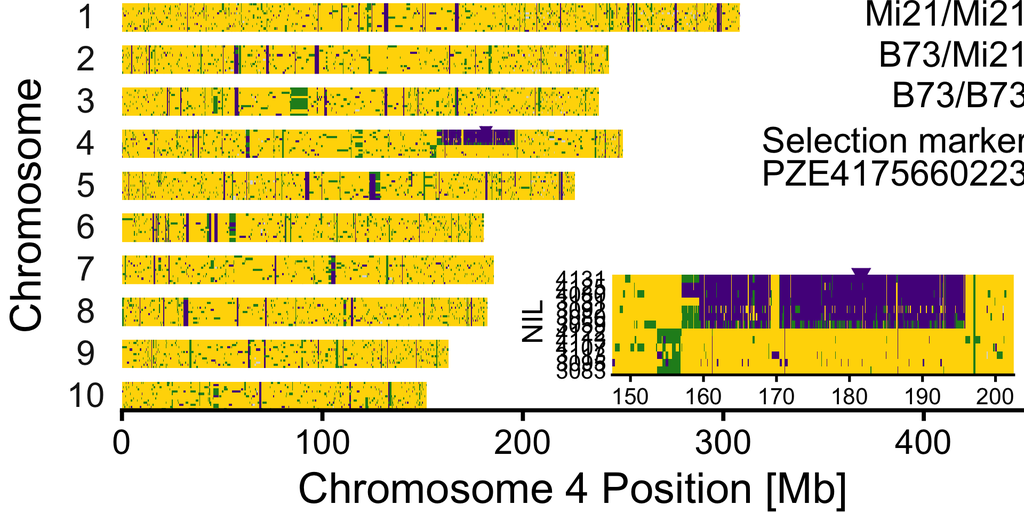

```r
# Random spike IDs for SVG coordinate calibration (unique, won't collide)
set.seed(42)
spike_id_a <- paste0("XK", paste0(sample(c(0:9, letters[1:6]), 12, replace = TRUE), collapse = ""))
spike_id_b <- paste0("XK", paste0(sample(c(0:9, letters[1:6]), 12, replace = TRUE), collapse = ""))

# Chr4 detailed inset
inlay <- gt_runs %>%
  filter(chr == "S4") %>%
  ungroup() %>%
  mutate(chr = gsub("S", "", chr)) %>%
  ggplot(aes(x = span, y = ind, fill = gt)) +
  geom_col(width = 1) +
  scale_fill_gradientn(
    colours = gt_colors,
    values = scales::rescale(c(0, 1, 2)),
    limits = c(0, 2),
    na.value = "gray85"
  ) +
  annotate("point",
    x = 181.6, y = 14.4,
    shape = 25, size = 6, color = "purple4", fill = "purple4"
  ) +
  # Invisible diagonal spikes for SVG coordinate calibration
  annotate("text", x = 160, y = 2,  label = spike_id_a, alpha = 0, size = 1) +
  annotate("text", x = 190, y = 12, label = spike_id_b, alpha = 0, size = 1) +
  coord_cartesian(xlim = c(150, 200)) +
  xlab(NULL) +
  ylab("NIL") +
  ggpubr::theme_classic2(base_size = 20) +
  theme(
    legend.position = "none",
    strip.background = element_blank(),
    strip.text = element_blank(),
    plot.title = element_blank(),
    axis.ticks.y = element_blank(),
    axis.line.y = element_blank(),
    plot.background = element_rect(fill = "transparent", color = NA),
    plot.margin = margin(t = 0, r = 0, b = 26, l = 0, unit = "mm")
  )

# Combine plots with annotation brackets
# First build base composite, then save SVG skeleton for coordinate extraction,
# then add annotations.

plot_base <- ggdraw() +
  draw_plot(gt_plot) +
  draw_plot(inlay,
    x = 0.45, y = 0.03 - 19 / (8 * 25.4),
    width = 0.6, height = 0.6,
    scale = 0.8
  )

# Save skeleton SVG for coordinate calibration
ggsave(file.path(paths$figures, "Fig1_panel_EF_skeleton.svg"),
       plot = plot_base, width = 18, height = 8, device = "svg",
       fix_text_size = TRUE)

plot_base
```

Extract annotation bracket positions from the skeleton SVG spike markers.

```r
# --- Parse spike markers from skeleton SVG ---
# spike_id_a is at data (160 Mb, y=2), spike_id_b at (190 Mb, y=12)
svg_path <- file.path(paths$figures, "Fig1_panel_EF_skeleton.svg")
svg_lines <- readLines(svg_path)

extract_spike <- function(lines, label) {
  idx <- grep(label, lines, fixed = TRUE)
  stopifnot(length(idx) == 1)
  line <- lines[idx]
  sx <- as.numeric(sub(".*x='([^']+)'.*", "\\1", line))
  sy <- as.numeric(sub(".*y='([^']+)'.*", "\\1", line))
  c(x = sx, y = sy)
}

spike_a <- extract_spike(svg_lines, spike_id_a)  # data: (160, 2)
spike_b <- extract_spike(svg_lines, spike_id_b)  # data: (190, 12)

svg_header <- svg_lines[grep("viewBox", svg_lines)[1]]
svg_W <- as.numeric(sub(".*viewBox='0 0 ([0-9.]+) .*", "\\1", svg_header))
svg_H <- as.numeric(sub(".*viewBox='0 0 [0-9.]+ ([0-9.]+)'.*", "\\1", svg_header))

# Linear mapping: data Mb → NPC x  (via SVG pixels)
# SVG x = a_x * Mb + b_x, then NPC = SVG_x / svg_W
a_x <- (spike_b["x"] - spike_a["x"]) / (190 - 160)
b_x <- spike_a["x"] - a_x * 160

mb_to_npc <- function(mb) {
  svg_x <- unname(a_x * mb + b_x)
  svg_x / svg_W
}

# Linear mapping: data y-index → NPC y  (SVG y is top-down, NPC is bottom-up)
# SVG y = a_y * data_y + b_y, then NPC = 1 - SVG_y / svg_H
a_y <- (spike_b["y"] - spike_a["y"]) / (12 - 2)
b_y <- spike_a["y"] - a_y * 2

data_y_to_npc <- function(dy) {
  svg_y <- unname(a_y * dy + b_y)
  1 - svg_y / svg_H
}

cat(sprintf("Spike A SVG: (%.2f, %.2f)\nSpike B SVG: (%.2f, %.2f)\n",
            spike_a["x"], spike_a["y"], spike_b["x"], spike_b["y"]))
```

```
## Spike A SVG: (851.23, 460.93)
## Spike B SVG: (1156.04, 333.21)
```

```r
cat(sprintf("SVG canvas: %.0f x %.0f\n", svg_W, svg_H))
```

```
## SVG canvas: 1296 x 576
```

```r
# --- Compute NPC positions for annotations ---
col_inv4m <- "purple4"

introg_left  <- mb_to_npc(introgression_start / 1e6)
introg_right <- mb_to_npc(introgression_end / 1e6)
inv4m_left   <- mb_to_npc(inv4m_start / 1e6)
inv4m_right  <- mb_to_npc(inv4m_end / 1e6)

introg_size_mb <- round((introgression_end - introgression_start) / 1e6)
inv4m_size_mb  <- round((inv4m_end - inv4m_start) / 1e6)

# y: bracket above inlay top, rectangle spans inlay data area
# Inlay y-data ranges ~0.5 (bottom bar) to ~14 (top bar)
y_inv4m_top <- data_y_to_npc(14)    # top of heatmap
y_inv4m_bot <- data_y_to_npc(0.5)   # bottom of heatmap
y_introg    <- y_inv4m_top + 0.025   # bracket just above

cat(sprintf("introg_left=%.4f  introg_right=%.4f\n", introg_left, introg_right))
```

```
## introg_left=0.6334  introg_right=0.9383
```

```r
cat(sprintf("inv4m_left=%.4f   inv4m_right=%.4f\n", inv4m_left, inv4m_right))
```

```
## inv4m_left=0.7578   inv4m_right=0.8774
```

```r
cat(sprintf("y_inv4m_top=%.4f  y_inv4m_bot=%.4f  y_introg=%.4f\n",
            y_inv4m_top, y_inv4m_bot, y_introg))
```

```
## y_inv4m_top=0.4659  y_inv4m_bot=0.1665  y_introg=0.4909
```

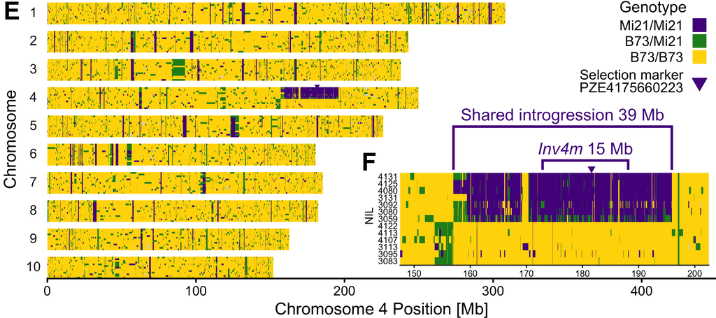

```r
# Layout (bottom to top):
#   inlay heatmap top edge = y_inv4m_top
#   Inv4m bracket just above heatmap
#   Inv4m label above that
#   Shared introgression bracket above Inv4m label
#   Shared introgression label at top
# Position bracket stack above inlay heatmap top
line_h           <- 1.2 * 25 / svg_H   # 1.2 lines in NPC
triangle_h       <- 3 * 72 / 25.4 / svg_H  # NPC height of size=3 triangle glyph
inv4m_tick_h     <- 0.04 - triangle_h   # shorten arms by triangle height
shift_down       <- 1.2 * (0.04)        # close gap to heatmap (original arm length)
y_inv4m_arms_bot <- y_inv4m_top + line_h - shift_down

mm_npc           <- function(mm) mm * 72 / 25.4 / svg_H

y_inv4m_bracket  <- y_inv4m_arms_bot + inv4m_tick_h
y_inv4m_label    <- y_inv4m_bracket + mm_npc(7.7)  # +7.7mm above bracket bar

# Introgression bracket: raise bar so label-to-bar gap = 6.7mm (matching Inv4m)
# Label stays at bar + 20.2mm, so bar must be 20.2 - 6.7 = 13.5mm above Inv4m label
y_introg_bracket <- y_inv4m_label + mm_npc(14.0)
introg_tick_h    <- y_introg_bracket - y_inv4m_arms_bot  # arms reach inv4m level

# Helper: make a ⊓-shaped bracket grob (left tick ↓, horizontal, right tick ↓)
make_bracket <- function(xl, xr, y_top, tick, col, lwd) {
  draw_grob(grid::polylineGrob(
    x = unit(c(xl, xl, xr, xr), "npc"),
    y = unit(c(y_top - tick, y_top, y_top, y_top - tick), "npc"),
    gp = grid::gpar(col = col, lwd = lwd, lineend = "square", linejoin = "mitre")
  ))
}

plot_with_inset <- plot_base +
  # --- Inv4m bracket (arms down, above triangle marker) ---
  make_bracket(inv4m_left, inv4m_right, y_inv4m_bracket, inv4m_tick_h,
               col_inv4m, 6) +
  draw_label(
    expression(italic("Inv4m") ~ "15 Mb"),
    x = (inv4m_left + inv4m_right) / 2, y = y_inv4m_label,
    size = 30, fontface = "plain", color = col_inv4m, hjust = 0.5) +
  # --- Shared introgression bracket (arms reach inv4m level) ---
  make_bracket(introg_left, introg_right, y_introg_bracket, introg_tick_h,
               col_inv4m, 6) +
  draw_label(
    paste0("Shared introgression ", introg_size_mb, " Mb"),
    x = (introg_left + introg_right) / 2, y = y_introg_bracket + mm_npc(7.7),
    size = 30, fontface = "plain", color = col_inv4m, hjust = 0.5) +
  # Panel labels
  draw_label("E", x = 0.005, y = 0.995, size = 45, fontface = "bold",
             hjust = 0, vjust = 1) +
  draw_label("F", x = 0.505, y = 0.52, size = 45, fontface = "bold",
             hjust = 0, vjust = 1)

plot_with_inset
```

```r
saveRDS(plot_with_inset, file.path(paths$intermediate, "fig1_panel_E.rds"))
saveRDS(gt_plot, file.path(paths$intermediate, "fig1_panel_E_main.rds"))
saveRDS(inlay, file.path(paths$intermediate, "fig1_panel_E_inlay.rds"))

ggsave(file.path(paths$figures, "Fig1_panel_EF.png"),
       plot = plot_with_inset, width = 18, height = 8, dpi = 300, bg = "white")
ggsave(file.path(paths$figures, "Fig1_panel_EF.svg"),
       plot = plot_with_inset, width = 18, height = 8, device = "svg",
       fix_text_size = TRUE)
```

## Panel F: Selected NIL Haplotypes

**Purpose**: Create Panel F for Figure 3 showing haplotype map for 3 representative NIL lines.

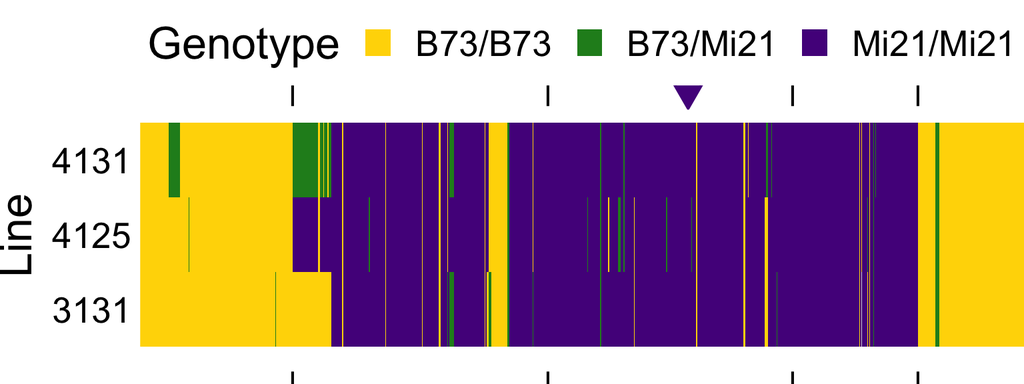

```r
# Selected samples for Panel F (representative NILs)
selected3 <- c("3131", "4125", "4131")

# Create Panel F plot
gt3_plot <- gt_runs %>%
  filter(chr == "S4", ind %in% selected3) %>%
  droplevels() %>%
  ungroup() %>%
  mutate(
    ind = factor(ind, levels = selected3),
    chr = gsub("S", "", chr)
  ) %>%
  ggplot(aes(x = span, y = ind, fill = gt)) +
  ylab("Line") +
  geom_col(width = 1) +
  scale_y_discrete(expand = c(0, 0)) +
  scale_fill_gradientn(
    colours = gt_colors,
    values = scales::rescale(c(0, 1, 2)),
    limits = c(0, 2),
    breaks = c(0, 1, 2),
    labels = gt_labels,
    na.value = "gray85"
  ) +
  guides(fill = guide_legend(title = "Genotype", ncol = 3)) +
  coord_cartesian(xlim = c(150, 200)) +
  annotate("point",
    x = 181.6, y = 4,
    shape = 25, size = 7, color = "purple4", fill = "purple4"
  ) +
  annotate("text",
    x = c(inversion_limit, introgression_limit), y = 4,
    label = rep("|", 4), size = 7
  ) +
  annotate("text",
    x = c(inversion_limit, introgression_limit), y = 0,
    label = rep("|", 4), size = 7
  ) +
  ggpubr::theme_classic2(base_size = 25) +
  theme(
    legend.position = "top",
    legend.byrow = TRUE,
    legend.text = element_text(size = 20),
    legend.box.spacing = unit(0, "pt"),
    plot.margin = unit(c(0, 0, 0, 0), "cm"),
    strip.background = element_blank(),
    strip.text = element_blank(),
    plot.title = element_text(color = "white"),
    axis.title.y = element_text(),
    axis.ticks.y = element_blank(),
    axis.line.y = element_blank(),
    axis.text.x = element_blank(),
    axis.title.x = element_blank(),
    axis.ticks.x = element_blank(),
    axis.line.x = element_blank(),
    plot.background = element_rect(fill = "transparent", color = NA)
  )

# Save as Panel F for Figure 3
ggsave(
  file.path(paths$figures, "panels", "panel_F_haplotype.png"),
  plot = gt3_plot,
  width = 8, height = 3, dpi = 300, bg = "white"
)
saveRDS(gt3_plot, file.path(paths$intermediate, "panel_F_haplotype.rds"))

gt3_plot
```

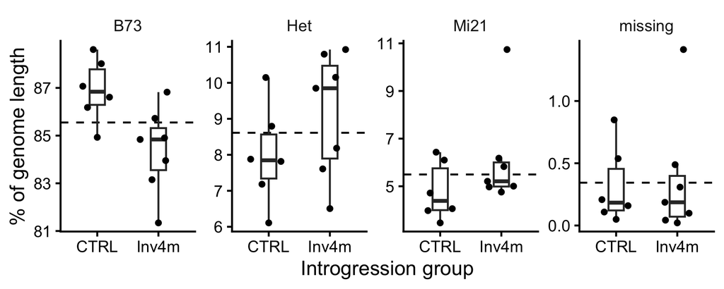

```r
# Background means
bg_mean <- by_length %>%
  ungroup() %>%
  group_by(Genotype) %>%
  summarise_at(.vars = c("length", "pct"), .funs = mean)

p_genotype <- by_length %>%
  ggplot(aes(x = group, y = pct)) +
  geom_hline(data = bg_mean, aes(yintercept = pct), linetype = 2) +
  geom_boxplot(outlier.colour = "white", width = 0.25) +
  ggbeeswarm::geom_quasirandom(size = 2) +
  facet_wrap(. ~ Genotype, scales = "free_y", ncol = 4) +
  xlab("Introgression group") +
  ylab("% of genome length") +
  ggpubr::theme_classic2(base_size = 20) +
  theme(strip.background = element_blank())

p_genotype
```

# Fixed Alternate Allele Analysis

**Purpose**: Quantify markers where the Mi21 (alternate) allele is fixed across all individuals, regardless of Inv4m genotype group. These markers cannot represent Inv4m-linked introgression because they are shared between CTRL and Inv4m carriers.

**Context**: Liang & Schnable (2016) showed that 2.3% of the B73 gene space carries divergent haplotypes across seed stocks, concentrated on chromosomes 2, 4, 5, and 6. Fixed alternate alleles in our NILs may reflect B73 seed stock divergence from the v5 reference rather than true Mi21 introgression.

```r
# Markers where all 13 individuals are homozygous for the alternate (Mi21) allele
# ngt is samples (rows) x markers (cols), coded 0/1/2
fixed_mi21 <- colSums(ngt, na.rm = FALSE) == (2 * nrow(ngt))
fixed_mi21[is.na(fixed_mi21)] <- FALSE

cat("Fixed alternate allele markers:", sum(fixed_mi21),
    "out of", ncol(ngt), "total\n\n")
```

```
## Fixed alternate allele markers: 1394 out of 19861 total
```

```r
# Compute run-length span per chromosome
# A "consensus fixed" vector: 2 where all individuals are Mi21, 0 elsewhere
consensus <- ifelse(fixed_mi21, 2, 0)
names(consensus) <- colnames(ngt)

fixed_runlength <- data.frame()
for (chr_idx in 1:10) {
  chr_prefix <- paste0("S", chr_idx, "_")
  chr_mask <- grepl(chr_prefix, names(consensus))
  chr_vals <- consensus[chr_mask]
  positions <- as.numeric(gsub(chr_prefix, "", names(chr_vals)))

  runs <- rle(chr_vals)
  run_starts <- cumsum(c(1, runs$lengths[-length(runs$lengths)]))

  chr_mb <- 0
  chr_markers <- 0
  for (i in seq_along(runs$values)) {
    if (runs$values[i] == 2) {
      start_pos <- positions[run_starts[i]]
      end_idx <- run_starts[i] + runs$lengths[i] - 1
      if (end_idx < length(positions)) {
        end_pos <- positions[end_idx + 1]
      } else {
        end_pos <- positions[end_idx]
      }
      chr_mb <- chr_mb + (end_pos - start_pos) / 1e6
      chr_markers <- chr_markers + runs$lengths[i]
    }
  }
  fixed_runlength <- rbind(fixed_runlength, data.frame(
    CHR = chr_idx, n_snps = chr_markers, runlength_Mb = round(chr_mb, 1)
  ))
}

fixed_runlength <- fixed_runlength %>%
  mutate(CHR = factor(CHR, levels = 1:10)) %>%
  arrange(desc(n_snps))

knitr::kable(fixed_runlength,
             caption = "Fixed alternate allele markers and genotype run-length by chromosome")
```

Fixed alternate allele markers and genotype run-length by chromosome

|  | CHR | n_snps | runlength_Mb |
| --- | --- | --- | --- |
| S1_192352 | 1 | 650 | 18.5 |
| S5_3621605 | 5 | 417 | 7.2 |
| S6_16767043 | 6 | 193 | 3.0 |
| S2_5281945 | 2 | 47 | 8.3 |
| S3_4704898 | 3 | 29 | 5.9 |
| S7_17158381 | 7 | 14 | 2.8 |
| S9_5227052 | 9 | 12 | 1.0 |
| S4_38429716 | 4 | 11 | 0.9 |
| S10_34702956 | 10 | 11 | 0.6 |
| S8_9251830 | 8 | 10 | 2.9 |

```r
cat("\nTotal:", sum(fixed_runlength$n_snps), "markers,",
    sum(fixed_runlength$runlength_Mb), "Mb\n")
```

```
##
## Total: 1394 markers, 51.1 Mb
```

```r
# How many are on chromosome 4?
n_fixed_chr4 <- fixed_runlength$n_snps[fixed_runlength$CHR == "4"]
pct_fixed_chr4 <- round(100 * n_fixed_chr4 / sum(fixed_mi21), 1)
cat("\nChromosome 4:", n_fixed_chr4, "markers (", pct_fixed_chr4, "% )\n")
```

```
##
## Chromosome 4: 11 markers ( 0.8 % )
```

```r
cat("Outside chromosome 4:", sum(fixed_mi21) - n_fixed_chr4, "markers (",
    round(100 - pct_fixed_chr4, 1), "% )\n")
```

```
## Outside chromosome 4: 1383 markers ( 99.2 % )
```

# Calculate Linkage Disequilibrium

**Purpose**: Quantify correlation between tagging SNP and all genome-wide markers.

**Approach**: Pearson correlation with S4_181558683 (within Inv4m). Pearson r² is the standard LD statistic for biallelic markers (Ardlie et al. 2002). FDR correction for multiple testing.

```r
# Calculate correlations
tagging_snp <- "S4_181558683"
cor_matrix <- cor(
  ngt[, tagging_snp, drop = FALSE],
  ngt,
  use = "pairwise.complete.obs"
) %>% t()

# Statistical testing
cor_pvalues <- apply(ngt, 2, function(x) {
  cor.test(x, y = ngt[, tagging_snp], method = "pearson")$p.value
})

# Combine results
significance_threshold <- 0.005
inv4m_cor <- data.frame(
  marker = rownames(cor_matrix),
  r = cor_matrix[, 1]
) %>%
  tidyr::separate(marker, into = c("CHR", "BP"), sep = "_") %>%
  mutate(
    BP = as.numeric(BP),
    CHR = gsub("S", "", CHR) %>% factor(levels = as.character(1:10)),
    p = cor_pvalues,
    FDR = p.adjust(p, method = "fdr"),
    R2 = r^2,
    is_significant = FDR < significance_threshold
  ) %>%
  tibble::rownames_to_column("ID")

cat("Total markers:", nrow(inv4m_cor), "\n")
```

```
## Total markers: 19861
```

```r
cat("Significant (FDR <", significance_threshold, "):",
    sum(inv4m_cor$is_significant, na.rm = TRUE),
    sprintf("(%.1f%%)", 100 * mean(inv4m_cor$is_significant, na.rm = TRUE)), "\n")
```

```
## Significant (FDR < 0.005 ): 7683 (44.8%)
```

```r
cat("Perfect LD (R² = 1):", sum(inv4m_cor$R2 == 1, na.rm = TRUE), "\n")
```

```
## Perfect LD (R² = 1): 3758
```

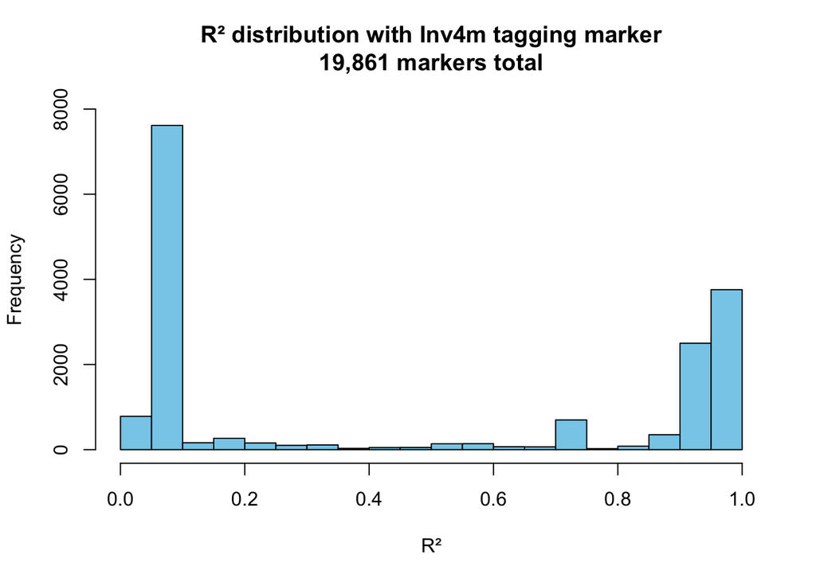

```r
hist(inv4m_cor$R2,
     main = "R² distribution with Inv4m tagging marker\n19,861 markers total",
     xlab = "R²",
     ylim = c(0, 8000),
     col = "skyblue",
     breaks = 30)
```

# Identify Correlated Regions

**Purpose**: Map SNPs with significant LD to genomic features.

**Approach**: Create GRanges from significant SNPs, classify by position relative to introgression boundaries.

```r
# All significant SNPs
correlated_SNP <- with(inv4m_cor %>% filter(is_significant), {
  GRanges(
    seqnames = CHR,
    ranges = IRanges(start = BP, end = BP),
    ID = ID
  )
})

# Outside shared introgression
outside_correlated <- inv4m_cor %>%
  filter(is_significant) %>%
  filter(!(CHR == 4 & BP >= introgression_start & BP <= introgression_end))

# Anti-correlated region (upstream of introgression)
anticorrelated_start <- 154283637
anticorrelated_end <- 156985577

anticorrelated <- correlated_SNP %>%
  subset(seqnames == 4 & start >= anticorrelated_start & end <= anticorrelated_end)

# Inside shared introgression (39 Mb region, not just Inv4m proper)
inside_correlated <- correlated_SNP %>%
  subset(seqnames == 4 & start >= introgression_start & end <= introgression_end)

cat("Correlated SNPs by location:\n")
```

```
## Correlated SNPs by location:
```

```r
cat("  Total significant:", length(correlated_SNP), "\n")
```

```
##   Total significant: 7683
```

```r
cat("  Inside shared introgression (39 Mb):", length(inside_correlated),
    sprintf("(%.1f%%)", 100 * length(inside_correlated) / length(correlated_SNP)),
    "\n")
```

```
##   Inside shared introgression (39 Mb): 7322 (95.3%)
```

```r
cat("  Outside shared introgression:", nrow(outside_correlated),
    sprintf("(%.1f%%)", 100 * nrow(outside_correlated) / length(correlated_SNP)),
    "\n")
```

```
##   Outside shared introgression: 361 (4.7%)
```

```r
cat("  Anti-correlated upstream (2.7 Mb):", length(anticorrelated), "\n")
```

```
##   Anti-correlated upstream (2.7 Mb): 207
```

```r
cat("  Arithmetic check: inside + outside =",
    length(inside_correlated) + nrow(outside_correlated), "\n")
```

```
##   Arithmetic check: inside + outside = 7683
```

```r
# Run-length of correlated SNPs using proper genotype run-length encoding
# Same methodology as get_genotype_runs: rle on classification, span = distance to next run start
compute_sig_runlength <- function(all_markers_df, is_sig_vector) {
  total_mb <- 0
  for (chr_idx in 1:10) {
    chr_mask <- as.numeric(as.character(all_markers_df$CHR)) == chr_idx
    chr_data <- all_markers_df[chr_mask, ]
    chr_sig <- is_sig_vector[chr_mask]
    if (sum(chr_sig, na.rm = TRUE) == 0) next

    positions <- chr_data$BP
    runs <- rle(chr_sig)
    run_starts <- cumsum(c(1, runs$lengths[-length(runs$lengths)]))

    for (i in seq_along(runs$values)) {
      if (isTRUE(runs$values[i])) {
        start_pos <- positions[run_starts[i]]
        end_idx <- run_starts[i] + runs$lengths[i] - 1
        if (end_idx < length(positions)) {
          end_pos <- positions[end_idx + 1]
        } else {
          end_pos <- positions[end_idx]
        }
        total_mb <- total_mb + (end_pos - start_pos) / 1e6
      }
    }
  }
  total_mb
}

# Classify each marker
all_markers <- inv4m_cor %>% arrange(as.numeric(as.character(CHR)), BP)
is_inside_sig <- all_markers$is_significant &
  as.character(all_markers$CHR) == "4" &
  all_markers$BP >= introgression_start & all_markers$BP <= introgression_end
is_inside_sig[is.na(is_inside_sig)] <- FALSE

is_outside_sig <- all_markers$is_significant & !is_inside_sig
is_outside_sig[is.na(is_outside_sig)] <- FALSE

inside_runlength <- compute_sig_runlength(all_markers, is_inside_sig)
outside_runlength <- compute_sig_runlength(all_markers, is_outside_sig)

cat("\nGenotype run-length of correlated SNPs:\n")
```

```
##
## Genotype run-length of correlated SNPs:
```

```r
cat("  Inside shared introgression:", round(inside_runlength, 1), "Mb\n")
```

```
##   Inside shared introgression: 33.6 Mb
```

```r
cat("  Outside dispersed:", round(outside_runlength, 1), "Mb\n")
```

```
##   Outside dispersed: 16.6 Mb
```

```r
# Chromosome distribution of significant markers
cat("\nSignificant markers by chromosome:\n")
```

```
##
## Significant markers by chromosome:
```

```r
sig_by_chr <- with(inv4m_cor %>% filter(is_significant), table(CHR))
print(sig_by_chr)
```

```
## CHR
##    1    2    3    4    5    6    7    8    9   10
##   28    9    9 7547   30    4    4   27    7   18
```

# Gene Overlap Analysis

**Purpose**: Identify genes overlapping Inv4m-correlated regions to create filter list for downstream analyses.

**Approach**: Use GenomicRanges::findOverlaps to map significant SNPs to gene annotations. Classify genes by location: inside shared introgression, dispersed background, or anti-correlated upstream.

**Expected outcome**: Generate comprehensive list of genes to exclude from analyses aimed at identifying trans-regulatory effects of Inv4m.

```r
# Load transcript annotations
transcripts_gff <- rtracklayer::import(myGFF) %>%
  subset(type == "mRNA" & seqnames %in% 1:10)

transcripts <- as.data.frame(transcripts_gff)
transcripts$gene_id <- gsub("transcript:", "", transcripts$ID)
transcripts$gene_id <- gsub("_.*", "", transcripts$gene_id, perl = TRUE)

# Convert SNP sets to GRanges for overlap
outside_correlated_gr <- with(outside_correlated, {
  GRanges(
    seqnames = CHR,
    ranges = IRanges(start = BP, end = BP),
    ID = ID
  )
})

# 1. Outside shared introgression (dispersed background)
olap_outside <- findOverlaps(outside_correlated_gr, transcripts_gff,
                              ignore.strand = TRUE)
outside_correlated_genes <- transcripts$gene_id[subjectHits(olap_outside)] %>%
  sort() %>%
  unique()

cat("Outside shared introgression:\n")
```

```
## Outside shared introgression:
```

```r
cat("  SNPs:", length(outside_correlated_gr), "\n")
```

```
##   SNPs: 361
```

```r
cat("  Unique SNP positions:", length(unique(queryHits(olap_outside))), "\n")
```

```
##   Unique SNP positions: 269
```

```r
cat("  Genes overlapped:", length(outside_correlated_genes), "\n")
```

```
##   Genes overlapped: 52
```

```r
# 2. Anti-correlated upstream region (154.3-157.0 Mb)
olap_anti <- findOverlaps(anticorrelated, transcripts_gff,
                           ignore.strand = TRUE)
anticorrelated_genes <- transcripts$gene_id[subjectHits(olap_anti)] %>%
  sort() %>%
  unique()

cat("\nAnti-correlated upstream (154.3-157.0 Mb):\n")
```

```
##
## Anti-correlated upstream (154.3-157.0 Mb):
```

```r
cat("  SNPs:", length(anticorrelated), "\n")
```

```
##   SNPs: 207
```

```r
cat("  Unique SNP positions:", length(unique(queryHits(olap_anti))), "\n")
```

```
##   Unique SNP positions: 177
```

```r
cat("  Genes overlapped:", length(anticorrelated_genes), "\n")
```

```
##   Genes overlapped: 14
```

```r
# 3. Inside shared introgression (157.0-195.9 Mb, 35 Mb)
olap_inside <- findOverlaps(inside_correlated, transcripts_gff,
                             ignore.strand = TRUE)
inside_correlated_genes <- transcripts$gene_id[subjectHits(olap_inside)] %>%
  sort() %>%
  unique()

cat("\nInside shared introgression (157.0-195.9 Mb):\n")
```

```
##
## Inside shared introgression (157.0-195.9 Mb):
```

```r
cat("  SNPs:", length(inside_correlated), "\n")
```

```
##   SNPs: 7322
```

```r
cat("  Unique SNP positions:", length(unique(queryHits(olap_inside))), "\n")
```

```
##   Unique SNP positions: 6910
```

```r
cat("  Gene models overlapped:", length(inside_correlated_genes), "\n")
```

```
##   Gene models overlapped: 512
```

```r
# Filter to expressed genes only (genes present in expression matrix)
expr_matrix <- read.csv(file.path(paths$intermediate, "PSU2022_gene_expression_matrix.csv"),
                        row.names = 1, check.names = FALSE)
expressed_genes <- rownames(expr_matrix)

inside_expressed <- inside_correlated_genes[inside_correlated_genes %in% expressed_genes]
outside_expressed <- outside_correlated_genes[outside_correlated_genes %in% expressed_genes]
anti_expressed <- anticorrelated_genes[anticorrelated_genes %in% expressed_genes]

cat("\nExpressed gene counts (genes in RNA-seq expression matrix):\n")
```

```
##
## Expressed gene counts (genes in RNA-seq expression matrix):
```

```r
cat("  Inside shared introgression:", length(inside_expressed), "expressed genes\n")
```

```
##   Inside shared introgression: 512 expressed genes
```

```r
cat("  Outside dispersed:", length(outside_expressed), "expressed genes\n")
```

```
##   Outside dispersed: 52 expressed genes
```

```r
cat("  Anti-correlated upstream:", length(anti_expressed), "expressed genes\n")
```

```
##   Anti-correlated upstream: 14 expressed genes
```

```r
# 4. Create filter list and classification table
# Only filter genes OUTSIDE the introgression that are correlated
# Note: anticorrelated genes are a SUBSET of outside_correlated genes
# (they're outside the introgression, specifically in the upstream region)

# Filter list is simply all outside genes (includes anticorrelated as subset)
outside_inv4m_genes <- outside_correlated_genes

cat("\nGenes to filter out (outside Inv4m but correlated):",
    length(outside_inv4m_genes), "\n")
```

```
##
## Genes to filter out (outside Inv4m but correlated): 52
```

```r
cat("  Total outside (includes anti-correlated):", length(outside_correlated_genes), "\n")
```

```
##   Total outside (includes anti-correlated): 52
```

```r
cat("  Anti-correlated subset:", length(anticorrelated_genes),
    sprintf("(%.1f%% of outside)", 100 * length(anticorrelated_genes) / length(outside_correlated_genes)),
    "\n")
```

```
##   Anti-correlated subset: 14 (26.9% of outside)
```

```r
# Create classification table for all correlated genes
# Anti-correlated genes get their own label even though they're subset of outside
gene_classification <- data.frame(
  gene_id = c(inside_correlated_genes,
              outside_correlated_genes),
  classification = c(
    rep("inside_introgression", length(inside_correlated_genes)),
    rep("outside_dispersed", length(outside_correlated_genes))
  )
) %>%
  distinct() %>%
  mutate(
    classification = ifelse(
      gene_id %in% anticorrelated_genes,
      "outside_anticorrelated",
      classification
    )
  )

cat("\nTotal genes correlated with Inv4m:", nrow(gene_classification), "\n")
```

```
##
## Total genes correlated with Inv4m: 564
```

```r
cat("  Inside introgression:", sum(gene_classification$classification == "inside_introgression"), "\n")
```

```
##   Inside introgression: 512
```

```r
cat("  Outside dispersed:", sum(gene_classification$classification == "outside_dispersed"), "\n")
```

```
##   Outside dispersed: 38
```

```r
cat("  Outside anti-correlated:", sum(gene_classification$classification == "outside_anticorrelated"), "\n")
```

```
##   Outside anti-correlated: 14
```

```r
# Save filter list (only outside genes)
saveRDS(outside_inv4m_genes, file.path(paths$intermediate, "inv4m_linked_genes_to_filter.rds"))
write.table(
  data.frame(gene_id = outside_inv4m_genes),
  file = file.path(paths$intermediate, "inv4m_linked_genes_to_filter.txt"),
  row.names = FALSE,
  quote = FALSE
)

# Save complete classification table
write.table(
  gene_classification,
  file = file.path(paths$intermediate, "inv4m_correlated_genes_classification.txt"),
  row.names = FALSE,
  quote = FALSE,
  sep = "\t"
)
saveRDS(gene_classification, file.path(paths$intermediate, "inv4m_correlated_genes_classification.rds"))

cat("\nFiles saved:\n")
```

```
##
## Files saved:
```

```r
cat("  Filter list (outside genes only):\n")
```

```
##   Filter list (outside genes only):
```

```r
cat("    - inv4m_linked_genes_to_filter.rds\n")
```

```
##     - inv4m_linked_genes_to_filter.rds
```

```r
cat("    - inv4m_linked_genes_to_filter.txt\n")
```

```
##     - inv4m_linked_genes_to_filter.txt
```

```r
cat("  Classification table (all correlated genes):\n")
```

```
##   Classification table (all correlated genes):
```

```r
cat("    - inv4m_correlated_genes_classification.txt\n")
```

```
##     - inv4m_correlated_genes_classification.txt
```

```r
cat("    - inv4m_correlated_genes_classification.rds\n")
```

```
##     - inv4m_correlated_genes_classification.rds
```

## Gene Overlap of Fixed Alternate Allele Markers

**Purpose**: Quantify how many fixed alternate allele markers (computed in the Fixed Alternate Allele Analysis section above) overlap expressed gene models. This is the gene-level count corresponding to the “fixed highland introgression” category in the manuscript.

```r
# Build GRanges for fixed markers
fixed_markers <- data.frame(
  marker = colnames(ngt)[fixed_mi21],
  stringsAsFactors = FALSE
) %>%
  mutate(
    CHR = gsub("^S(\\d+)_.*", "\\1", marker),
    BP = as.numeric(gsub("^S\\d+_", "", marker))
  )

fixed_gr <- GRanges(
  seqnames = fixed_markers$CHR,
  ranges = IRanges(start = fixed_markers$BP, end = fixed_markers$BP)
)

# Overlap with gene models (transcripts_gff loaded in gene_overlap chunk)
olap_fixed <- findOverlaps(fixed_gr, transcripts_gff, ignore.strand = TRUE)
fixed_snps_in_genes <- length(unique(queryHits(olap_fixed)))
fixed_genes <- transcripts$gene_id[subjectHits(olap_fixed)] %>%
  sort() %>% unique()

cat("Fixed alternate allele markers overlapping gene models:\n")
```

```
## Fixed alternate allele markers overlapping gene models:
```

```r
cat("  Total fixed markers:", sum(fixed_mi21), "\n")
```

```
##   Total fixed markers: 1394
```

```r
cat("  Markers in genes:", fixed_snps_in_genes, "\n")
```

```
##   Markers in genes: 1088
```

```r
cat("  Unique genes:", length(fixed_genes), "\n")
```

```
##   Unique genes: 162
```

```r
# Breakdown by chromosome
fixed_gene_markers <- fixed_markers[queryHits(olap_fixed), ] %>% distinct()
fixed_gene_by_chr <- fixed_gene_markers %>%
  group_by(CHR) %>%
  summarise(n_snps_in_genes = n(), .groups = "drop")

cat("\nFixed markers in genes by chromosome:\n")
```

```
##
## Fixed markers in genes by chromosome:
```

```r
print(as.data.frame(fixed_gene_by_chr))
```

```
##    CHR n_snps_in_genes
## 1    1             603
## 2   10               5
## 3    2              27
## 4    3              16
## 5    4               9
## 6    5             389
## 7    6              15
## 8    7              10
## 9    8               7
## 10   9               7
```

## Example: Applying Filter to DE Results

```r
# Example showing how to filter DE results to exclude Inv4m-linked genes
# This removes genes outside Inv4m that show linkage (trans-effects/background)

# Load your DE results (example structure)
# de_results <- read.csv("differential_expression_results.csv")

# Filter out genes outside Inv4m that are correlated with it
de_filtered <- de_results %>%
  filter(!gene %in% outside_inv4m_genes)

# Compare before/after
cat("DE results before filtering:", nrow(de_results), "genes\n")
cat("DE results after filtering:", nrow(de_filtered), "genes\n")
cat("Genes removed:", nrow(de_results) - nrow(de_filtered), "\n")

# This filtered set excludes background linkage effects
# Genes inside Inv4m are retained (cis-regulatory effects of interest)
```

# SNP Distribution Analysis

**Purpose**: Compare genome-wide vs. Inv4m-linked marker distributions.

**Approach**: Calculate chromosome-specific proportions for all SNPs and significant Inv4m-correlated SNPs.

```r
inv4_distro <- data.frame(
  CHR = factor(1:10, levels = 1:10),
  all = with(inv4m_cor, table(CHR)) %>% as.numeric(),
  inv4m = with(inv4m_cor %>% filter(is_significant), table(CHR)) %>%
    as.numeric()
) %>%
  mutate(
    all_pct = 100 * all / sum(all),
    inv4m_pct = 100 * inv4m / sum(inv4m)
  )

cat("SNP distribution:\n")
```

```
## SNP distribution:
```

```r
cat("  Chr4 contains", inv4_distro$all[4], "SNPs (",
    round(inv4_distro$all_pct[4], 1), "% of total)\n")
```

```
##   Chr4 contains 8892 SNPs ( 44.8 % of total)
```

```r
cat("  Chr4 Inv4m-linked:", inv4_distro$inv4m[4], "SNPs (",
    round(inv4_distro$inv4m_pct[4], 1), "% of significant)\n")
```

```
##   Chr4 Inv4m-linked: 7547 SNPs ( 98.2 % of significant)
```

```r
cat("  Other chromosomes average:",
    round(mean(inv4_distro$all[-4]), 0), "SNPs per chromosome\n")
```

```
##   Other chromosomes average: 1219 SNPs per chromosome
```

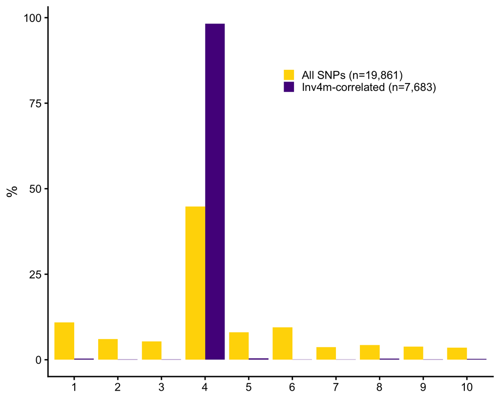

```r
p_distribution <- inv4_distro %>%
  tidyr::pivot_longer(
    cols = c("all_pct", "inv4m_pct"),
    names_to = "marker_type",
    values_to = "pct"
  ) %>%
  ggplot(aes(y = pct, x = CHR, group = marker_type, fill = marker_type)) +
  geom_bar(stat = "identity", position = "dodge") +
  scale_fill_manual(
    labels = c(
      sprintf("All SNPs (n=%s)", format(sum(inv4_distro$all), big.mark = ",")),
      sprintf("Inv4m-correlated (n=%s)", format(sum(inv4_distro$inv4m), big.mark = ","))
    ),
    values = c("gold", "purple4")
  ) +
  ylab("%") +
  ggpubr::theme_classic2(base_size = 20) +
  theme(
    legend.position = c(0.7, 0.8),
    legend.title = element_blank(),
    axis.title.x = element_blank()
  )

p_distribution
```

```r
# Save Supplementary Figure S1 (SNP distribution by chromosome).
ggsave(
  file.path(paths$figures, "SNP_distribution.png"),
  p_distribution,
  width = 8, height = 5, dpi = 300
)
ggsave(
  file.path(paths$figures, "SNP_distribution.svg"),
  p_distribution,
  width = 8, height = 5
)
```

# Manhattan Plots

**Purpose**: Visualize genome-wide LD patterns.

**Approach**: Plot -log10(FDR) and correlation coefficients across chromosomes.

```r
# Calculate cumulative positions
manhattan <- inv4m_cor %>%
  group_by(CHR) %>%
  summarise(chr_len = max(BP)) %>%
  mutate(tot = cumsum(chr_len) - chr_len) %>%
  select(-chr_len) %>%
  left_join(inv4m_cor, ., by = "CHR") %>%
  arrange(CHR, BP) %>%
  mutate(BPcum = BP + tot)

# Chromosome centers for x-axis
axisdf <- manhattan %>%
  group_by(CHR) %>%
  summarize(center = (max(BPcum) + min(BPcum)) / 2)

# Handle zero FDR values
manhattan$FDR[manhattan$FDR == 0] <- 1e-8
```

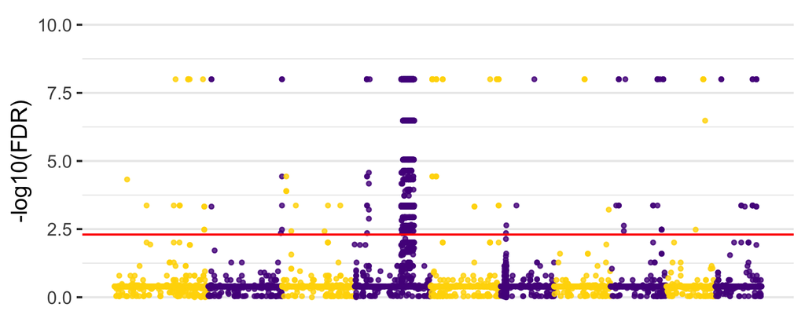

```r
p_fdr <- manhattan %>%
  ggplot(aes(x = BPcum, y = -log10(FDR))) +
  geom_point(aes(color = as.factor(CHR)), alpha = 0.8, size = 1.3) +
  scale_color_manual(values = rep(c("gold", "purple4"), 22)) +
  geom_hline(yintercept = -log10(significance_threshold), col = "red") +
  scale_x_continuous(label = axisdf$CHR, breaks = axisdf$center) +
  coord_cartesian(ylim = c(0, 10)) +
  theme_bw(base_size = 20) +
  theme(
    axis.title.x = element_blank(),
    axis.ticks.x = element_blank(),
    axis.text.x = element_blank(),
    legend.position = "none",
    panel.border = element_blank(),
    panel.grid.major.x = element_blank(),
    panel.grid.minor.x = element_blank()
  )

p_fdr
```

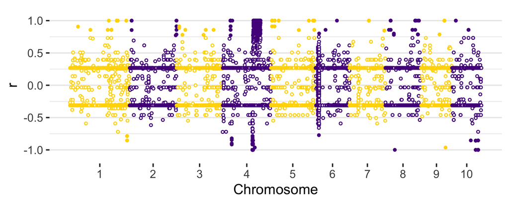

```r
p_r <- manhattan %>%
  ggplot(aes(x = BPcum, y = r)) +
  geom_point(aes(color = as.factor(CHR)), size = 1.3) +
  geom_point(
    data = manhattan %>% filter(FDR >= significance_threshold),
    aes(color = as.factor(CHR)),
    fill = "white",
    shape = 21,
    size = 1.3
  ) +
  scale_color_manual(values = rep(c("gold", "purple4"), 22)) +
  xlab("Chromosome") +
  scale_x_continuous(label = axisdf$CHR, breaks = axisdf$center) +
  coord_cartesian(ylim = c(-1.1, 1.1)) +
  theme_bw(base_size = 20) +
  theme(
    legend.position = "none",
    panel.border = element_blank(),
    panel.grid.major.x = element_blank(),
    panel.grid.minor.x = element_blank()
  )

p_r
```

# Combined Figure

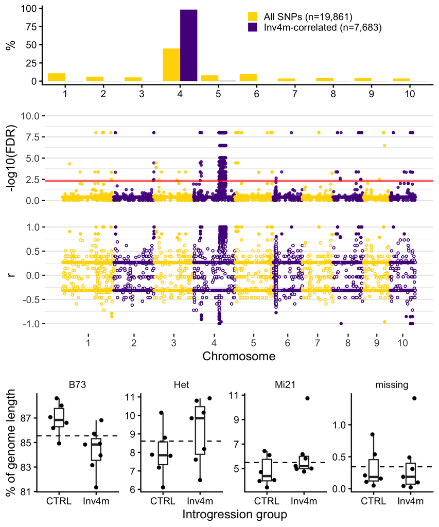

```r
combined <- ggpubr::ggarrange(
  p_distribution,
  p_fdr,
  p_r,
  p_genotype,
  nrow = 4,
  align = "hv",
  heights = c(2, 2, 3, 3)
)

combined
```

# Summary

```r
# LD statistics
ld_summary <- inv4m_cor %>%
  group_by(CHR) %>%
  summarise(
    total = n(),
    significant = sum(is_significant, na.rm = TRUE),
    pct_sig = round(100 * significant / total, 1),
    mean_r = round(mean(r, na.rm = TRUE), 3),
    mean_R2 = round(mean(R2, na.rm = TRUE), 3)
  )

knitr::kable(ld_summary, caption = "LD summary by chromosome")
```

LD summary by chromosome

| CHR | total | significant | pct_sig | mean_r | mean_R2 |
| --- | --- | --- | --- | --- | --- |
| 1 | 2173 | 28 | 1.3 | 0.038 | 0.104 |
| 2 | 1198 | 9 | 0.8 | -0.001 | 0.092 |
| 3 | 1069 | 9 | 0.8 | 0.027 | 0.095 |
| 4 | 8892 | 7547 | 84.9 | 0.801 | 0.829 |
| 5 | 1595 | 30 | 1.9 | 0.051 | 0.112 |
| 6 | 1885 | 4 | 0.2 | 0.028 | 0.085 |
| 7 | 731 | 4 | 0.5 | 0.015 | 0.091 |
| 8 | 854 | 27 | 3.2 | 0.043 | 0.114 |
| 9 | 762 | 7 | 0.9 | 0.041 | 0.093 |
| 10 | 702 | 18 | 2.6 | 0.002 | 0.114 |

```r
# Genotype composition
geno_summary <- by_length %>%
  group_by(group, Genotype) %>%
  summarise(
    mean_length = round(mean(length), 1),
    mean_pct = round(mean(pct), 1),
    .groups = "drop"
  )

knitr::kable(geno_summary, caption = "Mean genotype composition")
```

Mean genotype composition

| group | Genotype | mean_length | mean_pct |
| --- | --- | --- | --- |
| CTRL | B73 | 1849.3 | 86.9 |
| CTRL | Het | 170.0 | 8.0 |
| CTRL | Mi21 | 102.0 | 4.8 |
| CTRL | missing | 6.8 | 0.3 |
| Inv4m | B73 | 1795.9 | 84.4 |
| Inv4m | Het | 194.6 | 9.1 |
| Inv4m | Mi21 | 129.8 | 6.1 |
| Inv4m | missing | 7.8 | 0.4 |